# Fitting linear mixed-effects model using lme4

# Aim

To demostrate how to use lme4::lmer() function to fit linear mixed-effects models, and to compare these models. I also wanted to visualize the difference between the different models, and show how to do residual diagnostics automatically and manually. Also, I show a way to create (almost) publication-ready model comparison table.

We are going to use the built in sleepstudy dataset. It contains reaction times during 10 days of 3-hour-long sleep deprivation. It is a within-subject design, so in theory, it makes sense to use LMM.

| Subject | intercept | slope | fixed_slope | fixed_intercept |
| --- | --- | --- | --- | --- |
| 308 | 244.1927 | 21.764702 | 10.46729 | 251.4051 |
| 309 | 205.0549 | 2.261785 | 10.46729 | 251.4051 |
| 310 | 203.4842 | 6.114899 | 10.46729 | 251.4051 |
| 330 | 289.6851 | 3.008073 | 10.46729 | 251.4051 |
| 331 | 285.7390 | 5.266019 | 10.46729 | 251.4051 |
| 332 | 264.2516 | 9.566768 | 10.46729 | 251.4051 |
| 333 | 275.0191 | 9.142045 | 10.46729 | 251.4051 |
| 334 | 240.1629 | 12.253141 | 10.46729 | 251.4051 |
| 335 | 263.0347 | -2.881034 | 10.46729 | 251.4051 |
| 337 | 290.1041 | 19.025974 | 10.46729 | 251.4051 |

[output cut: 8 more lines]

# Step 1. Check the data like the observations were independent, i.e. use simple linear regression

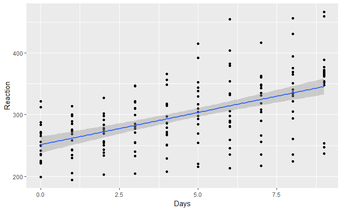

```r
# Create a plot that shows whis logic
ggplot(data = sleepstudy) +
    aes(x = Days, y = Reaction) +
    geom_point() +
    geom_smooth(method = "lm")
```

```r
# Fit liear regression
sleep.lm <- lm(Reaction ~ Days, data = sleepstudy)
# Check predictor statistics
summary(sleep.lm)
```

```
Call:
lm(formula = Reaction ~ Days, data = sleepstudy)

Residuals:
     Min       1Q   Median       3Q      Max
-110.848  -27.483    1.546   26.142  139.953

Coefficients:
            Estimate Std. Error t value Pr(>|t|)
(Intercept)  251.405      6.610  38.033  < 2e-16 ***
Days          10.467      1.238   8.454 9.89e-15 ***
---
Signif. codes:  0 ‘***’ 0.001 ‘**’ 0.01 ‘*’ 0.05 ‘.’ 0.1 ‘ ’ 1

Residual standard error: 47.71 on 178 degrees of freedom
Multiple R-squared:  0.2865,    Adjusted R-squared:  0.2825
F-statistic: 71.46 on 1 and 178 DF,  p-value: 9.894e-15
```

```r
tidy(sleep.lm)
```

| term | estimate | std.error | statistic | p.value |
| --- | --- | --- | --- | --- |
| (Intercept) | 251.40510 | 6.610154 | 38.033169 | 2.156888e-87 |
| Days | 10.46729 | 1.238195 | 8.453663 | 9.894096e-15 |

```r
# Check model fit statistics
glance(sleep.lm)
```

| r.squared | adj.r.squared | sigma | statistic | p.value | df | logLik | AIC | BIC | deviance | df.residual |
| --- | --- | --- | --- | --- | --- | --- | --- | --- | --- | --- |
| 0.2864714 | 0.2824628 | 47.71472 | 71.46442 | 9.894096e-15 | 2 | -950.1465 | 1906.293 | 1915.872 | 405251.6 | 178 |

Alternatively, we can plot the same regression on each participant, to see how far the fixed intercepts and slopes are from the data points.

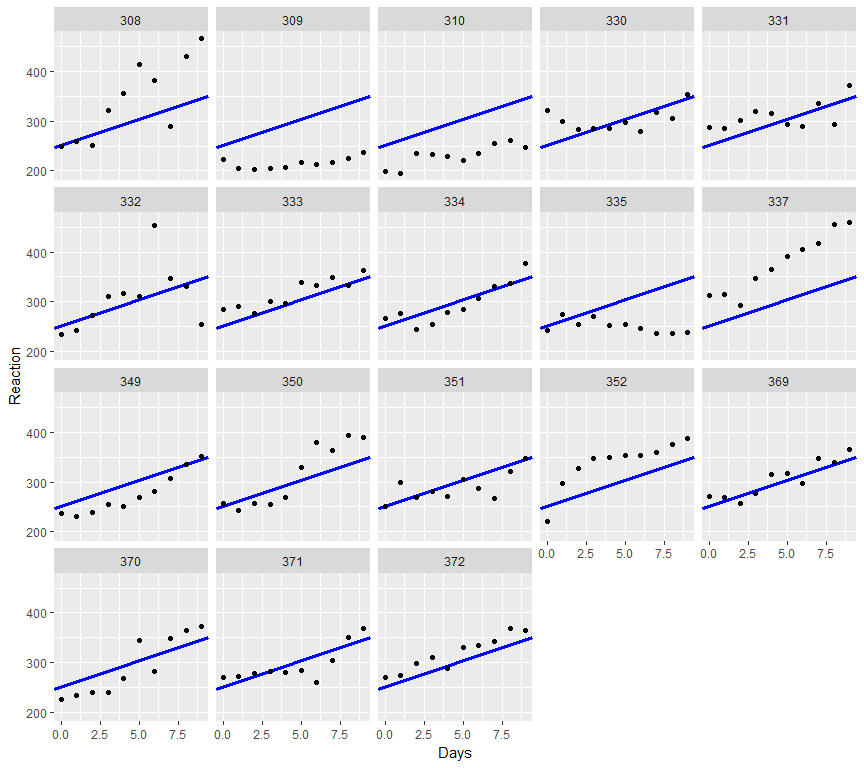

```r
# Plot the fixed intercept and slope model == linear regression
sleepstudy %>%
    left_join(subject_is) %>%
    ggplot() +
        aes(x = Days, y = Reaction) +
        geom_abline(aes(intercept = fixed_intercept, slope = fixed_slope), color = "blue", size = 1.2) +
        geom_point() +
        facet_wrap(~Subject)
```

Let’s also make a set of residual diagnostic plots.

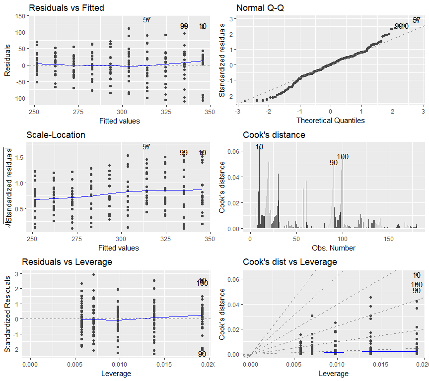

```r
# Residual diagnostic plots
autoplot(sleep.lm, which = 1:6)
```

# Step 2. Check if the mixed-model makes more sense

First try a random intercept model.

The lme4 syntax is very similar to the lm syntax. You can add random terms with + (slope|intercept). If you set the slope to 1, it means it remains fixed.

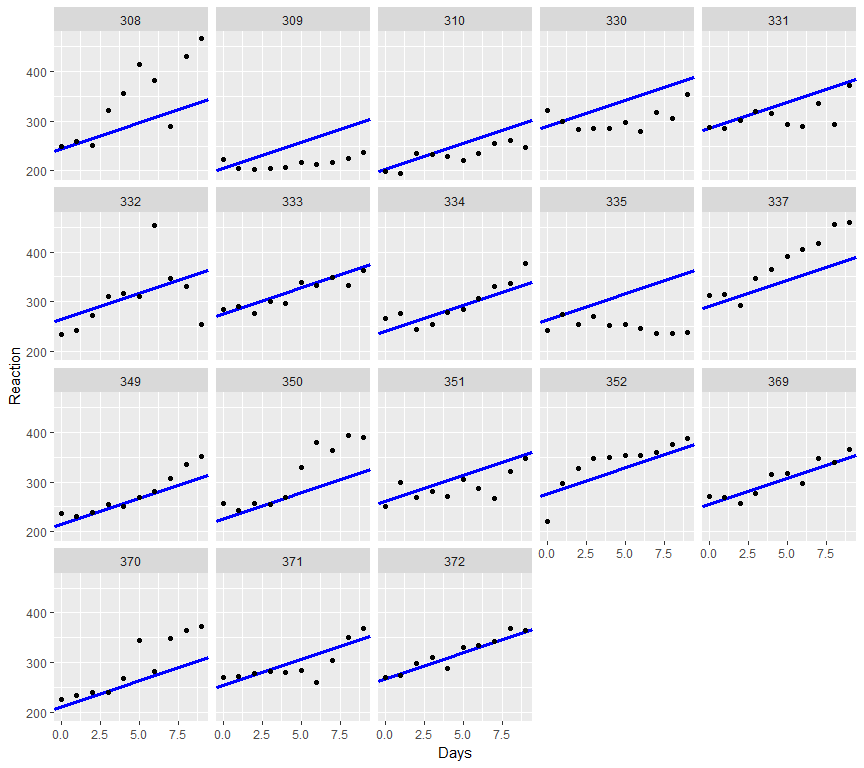

```r
# I want to show the fixed slope, random intercept model
# To do this, I fit an lm to each subject individually (see beginning of script). To get the fixed intercept, I take the average intercept in all models.
# Plot the random intercept model
sleepstudy %>%
    left_join(subject_is) %>%
    ggplot() +
        aes(x = Days, y = Reaction) +
        geom_abline(aes(intercept = intercept, slope = fixed_slope), color = "blue", size = 1.2) +
        geom_point() +
        facet_wrap(~Subject)
```

```r
# Fit the random intercept model
sleep.i <- lmer(Reaction ~ Days + (1|Subject), data = sleepstudy)
summary(sleep.i)
```

```
Linear mixed model fit by REML t-tests use Satterthwaite approximations to degrees of freedom [
lmerMod]
Formula: Reaction ~ Days + (1 | Subject)
   Data: sleepstudy

REML criterion at convergence: 1786.5

Scaled residuals:
    Min      1Q  Median      3Q     Max
-3.2257 -0.5529  0.0109  0.5188  4.2506

Random effects:
 Groups   Name        Variance Std.Dev.
 Subject  (Intercept) 1378.2   37.12
 Residual              960.5   30.99
Number of obs: 180, groups:  Subject, 18

Fixed effects:
            Estimate Std. Error       df t value Pr(>|t|)
(Intercept) 251.4051     9.7467  22.8100   25.79   <2e-16 ***
Days         10.4673     0.8042 161.0000   13.02   <2e-16 ***
---
Signif. codes:  0 ‘***’ 0.001 ‘**’ 0.01 ‘*’ 0.05 ‘.’ 0.1 ‘ ’ 1

Correlation of Fixed Effects:
     (Intr)
Days -0.371
```

```r
glance(sleep.i)
```

```
deviance() is deprecated for REML fits; use REMLcrit for the REML criterion or deviance(.,REML=FALSE) for deviance calculated at the REML fit
```

| sigma | logLik | AIC | BIC | deviance | df.residual |
| --- | --- | --- | --- | --- | --- |
| 30.99123 | -893.2325 | 1794.465 | 1807.237 | 1786.465 | 176 |

We can see that the model looks better, but the predicted values are sometimes quite off, e.g. with particpant 308 and 335.

## Let’s compare the random intercept model with the linear regression model.

The one with the random intercept has a much better fit, although it is more compex. lme4 by default uses REML for fitting the model, but when we are comparing models, it automatically refits the models in ML, so they are comparable.

```r
# Compare random intercept model to fixed intercept model (linear regression)
anova(sleep.i, sleep.lm)
```

```
refitting model(s) with ML (instead of REML)
```

```
Data: sleepstudy
Models:
..1: Reaction ~ Days
object: Reaction ~ Days + (1 | Subject)
       Df    AIC    BIC  logLik deviance  Chisq Chi Df Pr(>Chisq)
..1     3 1906.3 1915.9 -950.15   1900.3
object  4 1802.1 1814.8 -897.04   1794.1 106.21      1  < 2.2e-16 ***
---
Signif. codes:  0 ‘***’ 0.001 ‘**’ 0.01 ‘*’ 0.05 ‘.’ 0.1 ‘ ’ 1
```

# Let’s check if we need random slope too, or random intercept is enough

It turns out that the random intercept and slope model is the better fit, so it should be kept as final.

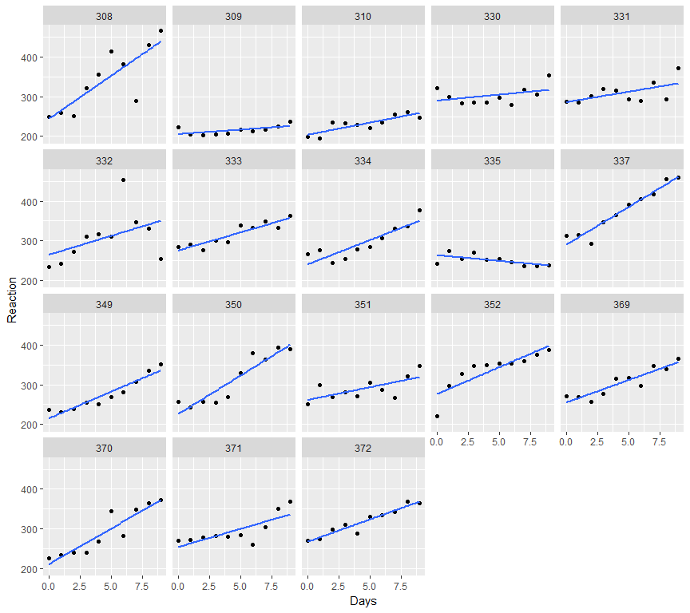

```r
# First, visualize how the data would look like with random intercept and slope. With ggplot, it is easy, beacause the geom_smooth(method = "lm") function does this automatically, we don't have to use our data from the earlier chunk.
ggplot(sleepstudy) +
    aes(x = Days, y = Reaction) +
    geom_point() +
    geom_smooth(method = "lm", se = FALSE) +
    facet_wrap(~Subject)
```

```r
# Fit random intercept and slope model
sleep.is <- lmer(Reaction ~ Days + (Days|Subject), data = sleepstudy)
summary(sleep.is)
```

```
Linear mixed model fit by REML t-tests use Satterthwaite approximations to degrees of freedom [
lmerMod]
Formula: Reaction ~ Days + (Days | Subject)
   Data: sleepstudy

REML criterion at convergence: 1743.6

Scaled residuals:
    Min      1Q  Median      3Q     Max
-3.9536 -0.4634  0.0231  0.4634  5.1793

Random effects:
 Groups   Name        Variance Std.Dev. Corr
 Subject  (Intercept) 612.09   24.740
          Days         35.07    5.922   0.07
 Residual             654.94   25.592
Number of obs: 180, groups:  Subject, 18

Fixed effects:
            Estimate Std. Error      df t value Pr(>|t|)
(Intercept)  251.405      6.825  17.000  36.838  < 2e-16 ***
Days          10.467      1.546  17.000   6.771 3.26e-06 ***
---
Signif. codes:  0 ‘***’ 0.001 ‘**’ 0.01 ‘*’ 0.05 ‘.’ 0.1 ‘ ’ 1

Correlation of Fixed Effects:
     (Intr)
Days -0.138
```

```r
glance(sleep.is)
```

```
deviance() is deprecated for REML fits; use REMLcrit for the REML criterion or deviance(.,REML=FALSE) for deviance calculated at the REML fit
```

| sigma | logLik | AIC | BIC | deviance | df.residual |
| --- | --- | --- | --- | --- | --- |
| 25.59182 | -871.8141 | 1755.628 | 1774.786 | 1743.628 | 174 |

```r
# Compare model to random intercept model
anova(sleep.i, sleep.is)
```

```
refitting model(s) with ML (instead of REML)
```

```
Data: sleepstudy
Models:
object: Reaction ~ Days + (1 | Subject)
..1: Reaction ~ Days + (Days | Subject)
       Df    AIC    BIC  logLik deviance  Chisq Chi Df Pr(>Chisq)
object  4 1802.1 1814.8 -897.04   1794.1
..1     6 1763.9 1783.1 -875.97   1751.9 42.139      2  7.072e-10 ***
---
Signif. codes:  0 ‘***’ 0.001 ‘**’ 0.01 ‘*’ 0.05 ‘.’ 0.1 ‘ ’ 1
```

# Residual diadnostics of the linear mixed-model

Sadly, the autoplot is not capable to make the residual diagnostic plots, but we can do it easily using the results of the augment() function. Despite the three outlier data points, the residuals look rather normal. We should accept this model as the final one.

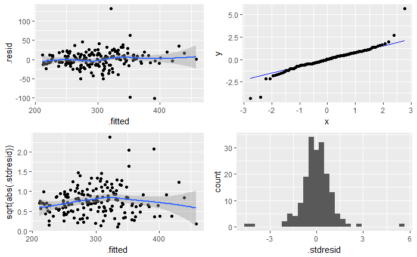

```r
# Get the residuals using the broom::augment() function
diag_data <- augment(sleep.is, sleepstudy) %>%
    mutate(.stdresid = scale(.resid) %>% as.numeric())
# Plot the data together in one object
plot_1 <- ggplot(diag_data) +
    aes(x = .fitted, y = .resid) +
    geom_point() +
    geom_smooth()
plot_2 <- ggplot(diag_data) +
    aes(x = .fitted, y = sqrt(abs(.stdresid))) +
    geom_point() +
    geom_smooth()
plot_3 <- ggplot(diag_data) +
    aes(sample = .stdresid) +
    geom_qq_line(color = "blue") +
    geom_qq()
plot_4 <- ggplot(diag_data) +
    aes(x = .stdresid) +
    geom_histogram(bins = 30)
gridExtra::grid.arrange(plot_1, plot_3, plot_2, plot_4)
```

# Print model comparison using stargazer

We need to refit the mixed-models using the lme4 version of lmer, as stargazer cannot read the lmerTest::lmer() object.

```r
# Refit LMMs in order to show in stargazer
sleep.i.final <- lme4::lmer(Reaction ~ Days + (1|Subject), data = sleepstudy)
sleep.is.final <- lme4::lmer(Reaction ~ Days + (Days|Subject), data = sleepstudy)
stargazer(sleep.lm, sleep.i.final, sleep.is.final, type = "html")
```

|  | *Dependent variable:* |  |  |
| --- | --- | --- | --- |
|  | Reaction |  |  |
|  | *OLS* | *linear* |  |
|  |  | *mixed-effects* |  |
|  | (1) | (2) | (3) |
| Days | 10.467*** | 10.467*** | 10.467*** |
|  | (1.238) | (0.804) | (1.546) |
| Constant | 251.405*** | 251.405*** | 251.405*** |
|  | (6.610) | (9.747) | (6.825) |
| Observations | 180 | 180 | 180 |
| R<sup>2</sup> | 0.286 |  |  |
| Adjusted R<sup>2</sup> | 0.282 |  |  |
| Log Likelihood |  | -893.233 | -871.814 |
| Akaike Inf. Crit. |  | 1,794.465 | 1,755.628 |
| Bayesian Inf. Crit. |  | 1,807.237 | 1,774.786 |
| Residual Std. Error | 47.715 (df = 178) |  |  |
| F Statistic | 71.464*** (df = 1; 178) |  |  |
| *Note:* | p<0.1; p<0.05; p<0.01 |  |  |